# R Notebook

This notebook is Tom’s analysis from raw data

```r
library(tidyverse)
```

```r
peptides_df <- parse_features(infile, silac=FALSE, TMT=FALSE, level="peptide", filter_crap=TRUE)
```

```
Tally of features at each stage:
29067   All features with a PSM
These features are associated with 2597 master proteins
27490   Excluding features without a master protein
These features are associated with 2596 master proteins
26424   Excluding features without a unique master protein
These features are associated with 2311 master proteins
26254   Excluding features matching a cRAP protein
These features are associated with 2301 master proteins
25987   Excluding features associated with a cRAP protein
These features are associated with 2283 master proteins
```

```r
peptides_quant <- makeMSNSet(obj=peptides_df, samples_inf=samples_inf, ab_col_ix=2, level="peptide", quant_name="Area")
```

```
tallies for missing data (# samples with missing)
   0    1    2    3    4    5    6    7    8    9   10   11   12   13   14   15   16   17   18   19   20
  16   35   98   99  100  119  141  144  224  278  327  386  517  684  930 1238 1696 2517 3981 8158 4299

4299 peptides do not have any quantification values
```

So lots and lots of missing values! most peptides are quantified in only a very minor subset of fractions (<5/20). This is no suprise since we’re dealing with LFQ and subcellular fractionation here.

```
Out of 21688 total features, 21672 (99.926%) have missing values

   1    2    3    4    5    6    7    8    9   10   11   12   13   14   15   16   17   18   19
  35   98   99  100  119  141  144  224  278  327  386  517  684  930 1238 1696 2517 3981 8158
And 21637 features have more than one missing value
```

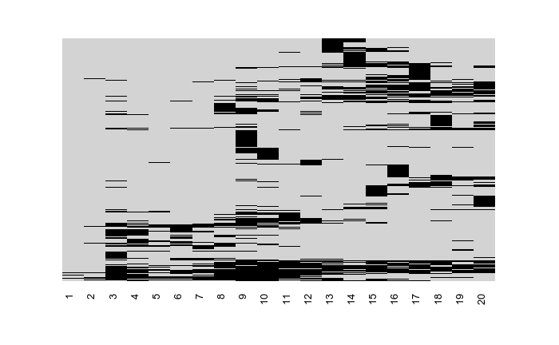

```r
plotMissing(peptides_quant)
```

What about if we subset to GO annotated RBPs?

|  | UNIPROTKB | GO.ID | TERM | ONTOLOGY |
| --- | --- | --- | --- | --- |
| 1 | Q02078 | GO:0000002 | mitochondrial genome maintenance | BP |
| 2 | P19971 | GO:0000002 | mitochondrial genome maintenance | BP |
| 3 | Q9NRX2 | GO:0000002 | mitochondrial genome maintenance | BP |
| 4 | P51530 | GO:0000002 | mitochondrial genome maintenance | BP |
| 5 | O95352 | GO:0000002 | mitochondrial genome maintenance | BP |
| 6 | P12235 | GO:0000002 | mitochondrial genome maintenance | BP |

```
Out of 11023 total features, 11012 (99.9%) have missing values

   1    2    3    4    5    6    7    8    9   10   11   12   13   14   15   16   17   18   19
  26   79   76   78   87  100  106  162  200  228  247  327  397  531  671  894 1253 1844 3706
And 10986 features have more than one missing value
```

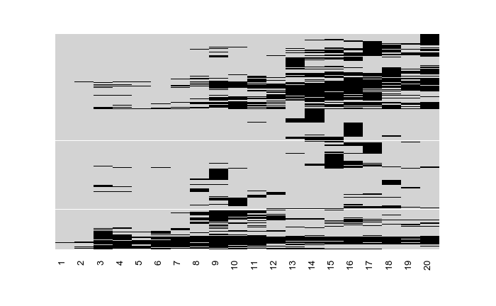

```r
peptides_quant[fData(peptides_quant)$master_protein %in% GO_RBPs,] %>% plotMissing()
```

Ok, so this doesn’t make any difference, 99.9% have a missing value!

Let’s aggregate to the unique peptide sequence level (ignorning variable modifications) and then see whether that reduces our problem

```r
peptides_no_mod_quant <- agg_to_peptides(peptides_quant)
```

```
Your data contains missing values. Please read the relevant section in the combineFeatures manual page for
details the effects of missing values on data aggregation.
```

Nope, not really! We still have 19304 features (previously 21688) and 99.9% have missing values!

```
Out of 19304 total features, 19288 (99.917%) have missing values

   1    2    3    4    5    6    7    8    9   10   11   12   13   14   15   16   17   18   19
  37  109  102   94  133  146  149  221  298  344  396  526  691  907 1204 1649 2389 3527 6366
And 19251 features have more than one missing value
```

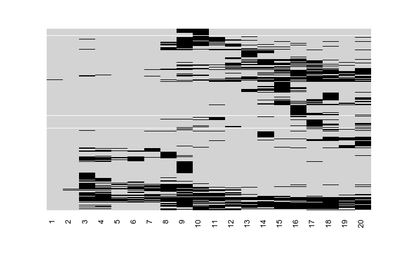

```r
plotMissing(peptides_no_mod_quant)
```

```
Out of 19304 total features, 19030 (98.581%) have missing values

   1    2    3    4    5    6    7    8    9   10   11   12   13
 247  302  312  352  451  558  774 1013 1511 2235 3382 6372 1521
And 18783 features have more than one missing value
```

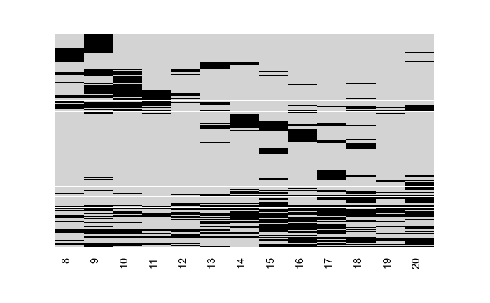

```r
peptides_no_mod_quant_no_lm <- peptides_no_mod_quant[,8:20]
plotMissing(peptides_no_mod_quant_no_lm)
```

If we focus on those peptides with 4-9 missing values, we can see that many are missing in a block of sequential fractions. Arguably, these are true missing values, e.g not at random.

```
Out of 4659 total features, 4659 (100%) have missing values

   4    5    6    7    8    9
 352  451  558  774 1013 1511
And 4659 features have more than one missing value
```

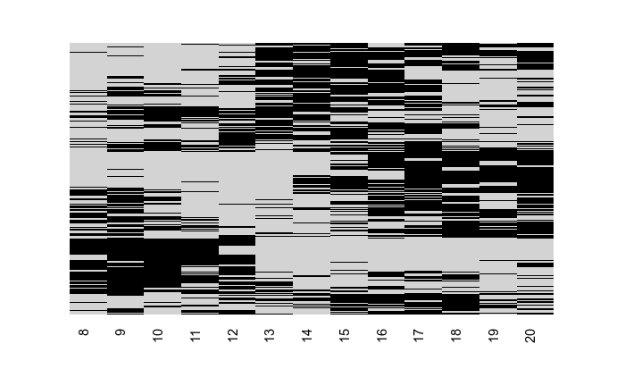

```r
missing_n <- rowSums(is.na(exprs(peptides_no_mod_quant_no_lm)))
peptides_no_mod_quant_no_lm[(missing_n>=4 & missing_n<=9),] %>% plotMissing()
```

First, let’s make a function to identify rows of values where the missing values are not random, e.g 4 or more in a row

```r
test_values_1 <- c(1,1,NA,1,NA,NA,1,1,1,1)
test_values_2 <- c(1,1,NA,NA,NA,NA,NA,1,1,1)
test_values_3 <- c(NA,NA,NA,NA,1,1,1,1,1)
is_not_at_random <- function(x){
  with(rle(is.na(x)), sum(lengths[values] >= 4))
}
is_not_at_random(test_values_1)
```

```
[1] 0
```

```r
is_not_at_random(test_values_2)
```

```
[1] 1
```

```r
is_not_at_random(test_values_3)
```

```
[1] 1
```

Now, let’s check this identifies the peptides which are not missing at random. First, we’ll remove those without at least 4 quantification values.

```r
peptides_no_mod_quant_4 <- peptides_no_mod_quant_no_lm[missing_n<=(13-4),]
missing_not_at_random <- apply(exprs(peptides_no_mod_quant_4), 1, is_not_at_random)
```

[output not shown]

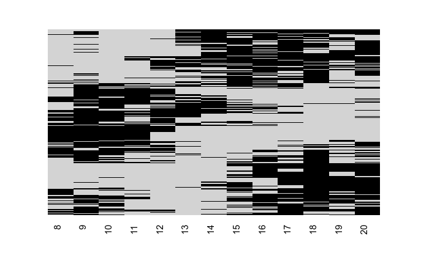

```r
peptides_no_mod_quant_4[missing_not_at_random==1,] %>% plotMissing()
```

[output not shown]

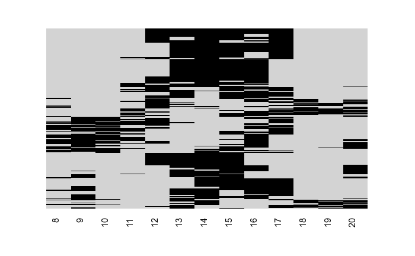

```r
peptides_no_mod_quant_4[missing_not_at_random==2,] %>% plotMissing()
```

Now, let’s extend the function to replace the blocks of missing values with zero

```r
test_values_1 <- c(1,1,NA,1,NA,NA,1,1,1,1)
test_values_2 <- c(1,1,NA,NA,NA,NA,NA,1,1,1)
test_values_3 <- c(NA,NA,NA,NA,1,1,1,1,1, NA)
rle(is.na(test_values_1))$values
```

```
[1] FALSE  TRUE FALSE  TRUE FALSE
```

```r
rle(is.na(test_values_1))$lengths
```

```
[1] 2 1 1 2 4
```

```r
replace_missing_not_at_random <- function(x){
  missing_rle <- rle(is.na(x))

  sequential_blocks <- missing_rle$values
  sequential_blocks[missing_rle$lengths<4] <- FALSE
  replace_with_zero <- rep(sequential_blocks, missing_rle$lengths)

  out <- x
  out[replace_with_zero]<-0

  return(out)
}
replace_missing_not_at_random(test_values_1)
```

```
 [1]  1  1 NA  1 NA NA  1  1  1  1
```

```r
replace_missing_not_at_random(test_values_2)
```

```
 [1] 1 1 0 0 0 0 0 1 1 1
```

```r
replace_missing_not_at_random(test_values_3)
```

```
 [1]  0  0  0  0  1  1  1  1  1 NA
```

```r
peptides_no_mod_quant_4_mnar_zero <- peptides_no_mod_quant_4
exprs(peptides_no_mod_quant_4_mnar_zero) <- exprs(peptides_no_mod_quant_4_mnar_zero) %>%
  apply(1, replace_missing_not_at_random) %>% t()
```

Re-check the missing values

```
Out of 5794 total features, 5520 (95.271%) have missing values

   1    2    3    4    5    6    7    8    9
 247  302  312  352  451  558  774 1013 1511
And 5273 features have more than one missing value
```

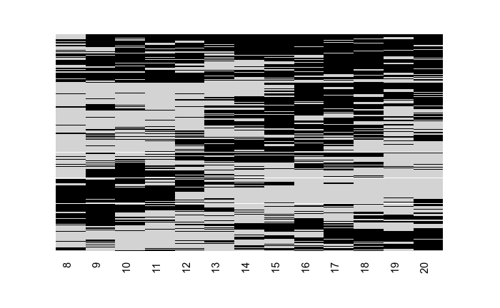

```r
plotMissing(peptides_no_mod_quant_4)
```

```
Out of 5794 total features, 4607 (79.513%) have missing values

   1    2    3    4    5    6    7    8    9
1129  999  918  646  389  252  162   79   33
And 3478 features have more than one missing value
```

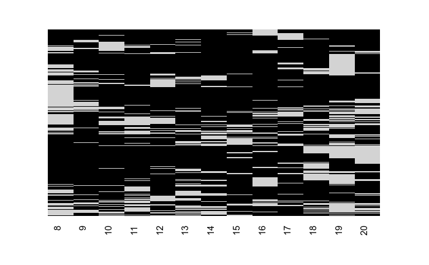

```r
plotMissing(peptides_no_mod_quant_4_mnar_zero)
```

```r
peptides_no_mod_quant_4_mnar_zero_mar_knn <- peptides_no_mod_quant_4_mnar_zero
imputed_zeros <- rowSums(exprs(peptides_no_mod_quant_4_mnar_zero_mar_knn)==0)
missing_n2 <- rowSums(is.na(exprs(peptides_no_mod_quant_4_mnar_zero_mar_knn)))
fData(peptides_no_mod_quant_4_mnar_zero_mar_knn)$zero_imputation <- imputed_zeros>0
fData(peptides_no_mod_quant_4_mnar_zero_mar_knn)$zero_imputation_n <- imputed_zeros
fData(peptides_no_mod_quant_4_mnar_zero_mar_knn)$missing <- missing_n2>0
fData(peptides_no_mod_quant_4_mnar_zero_mar_knn)$missing_n <- missing_n2
peptides_no_mod_quant_4_mnar_zero_mar_knn <- peptides_no_mod_quant_4_mnar_zero_mar_knn[missing_n2<=3,]
dim(peptides_no_mod_quant_4_mnar_zero)
```

```
[1] 5794   13
```

```r
dim(peptides_no_mod_quant_4_mnar_zero_mar_knn)
```

```
[1] 4233   13
```

```r
peptides_no_mod_quant_4_mnar_zero_mar_knn <- suppressMessages(impute(peptides_no_mod_quant_4_mnar_zero_mar_knn, "knn", k = 10))
```

```
Cluster size 4233 broken into 306 3927
Done cluster 306
Cluster size 3927 broken into 452 3475
Done cluster 452
Cluster size 3475 broken into 3090 385
Cluster size 3090 broken into 2436 654
Cluster size 2436 broken into 598 1838
Done cluster 598
Cluster size 1838 broken into 458 1380
Done cluster 458
Done cluster 1380
Done cluster 1838
Done cluster 2436
Done cluster 654
Done cluster 3090
Done cluster 385
Done cluster 3475
Done cluster 3927
```

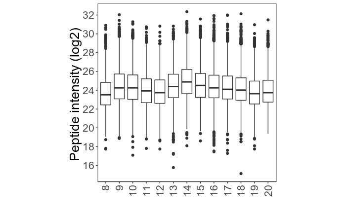

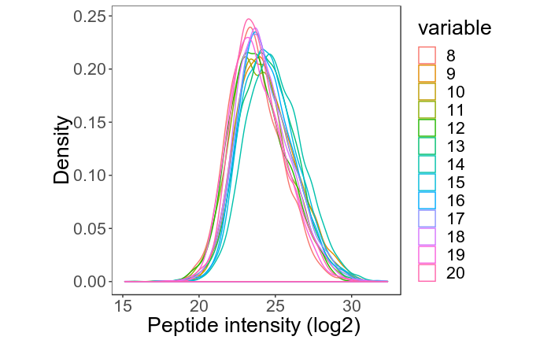

```r
p <- plotLabelQuant(peptides_no_mod_quant_no_lm, log=TRUE)
```

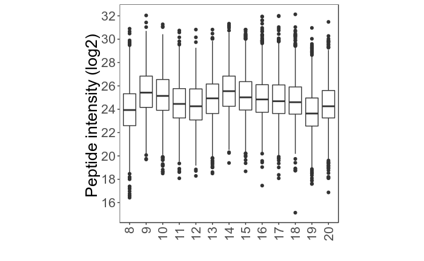

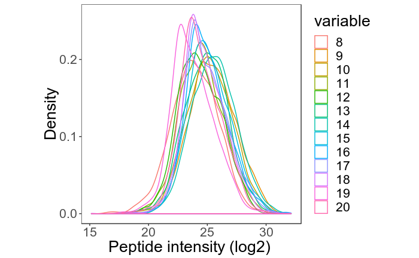

```r
p <- plotLabelQuant(peptides_no_mod_quant_4_mnar_zero_mar_knn, log=TRUE)
```

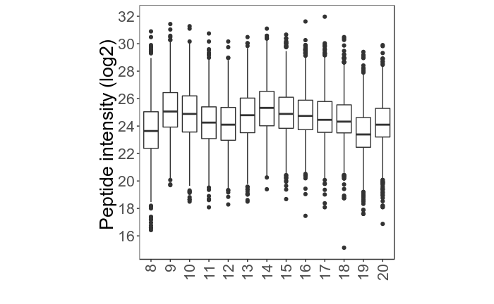

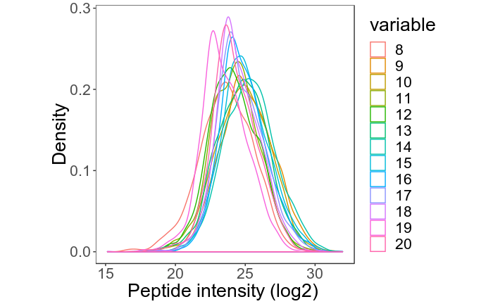

```r
p <- peptides_no_mod_quant_4_mnar_zero_mar_knn[
  fData(peptides_no_mod_quant_4_mnar_zero_mar_knn)$missing,] %>% plotLabelQuant(log=TRUE)
```

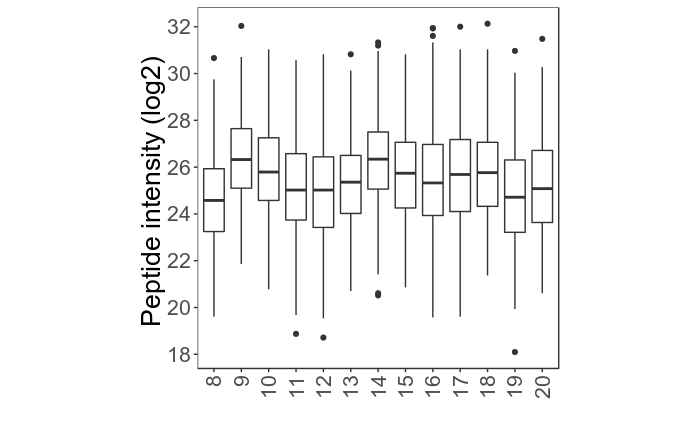

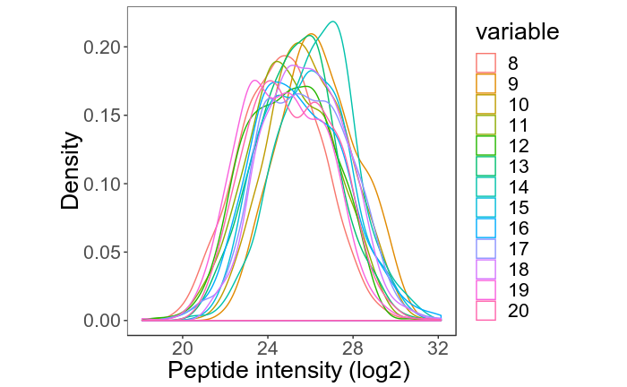

```r
p <- peptides_no_mod_quant_4_mnar_zero_mar_knn[
  !fData(peptides_no_mod_quant_4_mnar_zero_mar_knn)$missing,] %>% plotLabelQuant(log=TRUE)
```

```r
protein_quant <- agg_to_protein(peptides_no_mod_quant_4_mnar_zero_mar_knn)
print(dim(protein_quant))
```

```
[1] 911  13
```

```r
markers_df <- read.delim("./Input//markers_9B_hyperLOPIT_vs_DC.csv", sep=",", header=FALSE, stringsAsFactors=FALSE)[,1:2]
markers_df$V2 <- recode(markers_df$V2, "RIBOSOME 40S"="RIBOSOME", "RIBOSOME 60S"="RIBOSOME")
markers_proteins <- markers_df$V2
names(markers_proteins) <- markers_df$V1
protein_quant_am <- addMarkers(normalise(protein_quant, "sum"), markers_proteins)
```

```
Markers in data: 151 out of 911
```

```
organelleMarkers
          CYTOSOL                ER             GOLGI          LYSOSOME      MITOCHONDRIA           NUCLEUS
               13                24                 3                 2                13                21
NUCLEUS-CHROMATIN        PEROXISOME                PM        PROTEASOME          RIBOSOME           unknown
               10                 1                15                 5                44               760
```

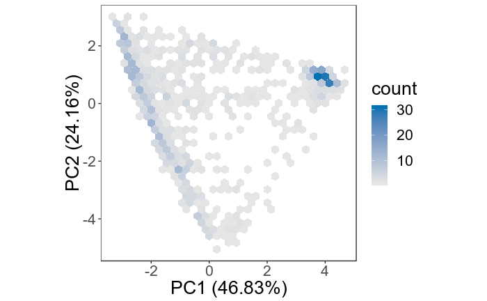

```r
p <- plotHexbin(protein_quant_am, "markers")
print(p)
```

```r
ggsave("~/Desktop/delete_me.png")
```

Copied from Manasa’s oopsFinal.Rmd notebook

```r
p <- plotPCA(protein_quant_am, "markers", m_colours=m_colours, re_order_markers=TRUE, marker_levels=organelle_order, foi=translocon)
```

```
the condition has length > 1 and only the first element will be used
```

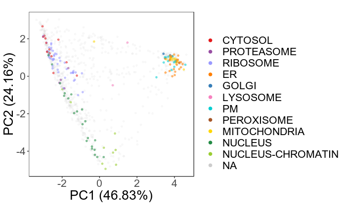

```r
print(p)
```

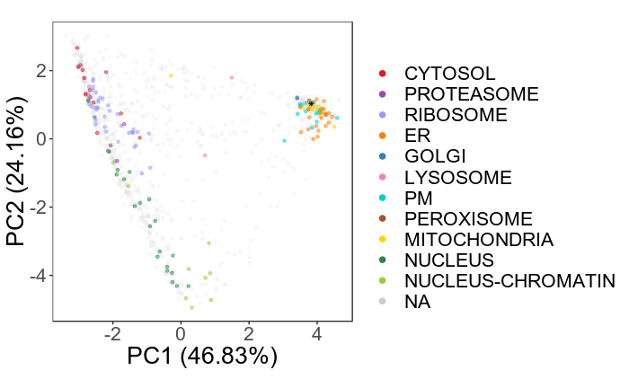

```r
ggsave("~/Desktop/delete_me2.png")
```

```r
p <- plotPCA(protein_quant_am, "markers", m_colours=m_colours, re_order_markers=TRUE, marker_levels=organelle_order, foi=para)
```

```
the condition has length > 1 and only the first element will be used
```

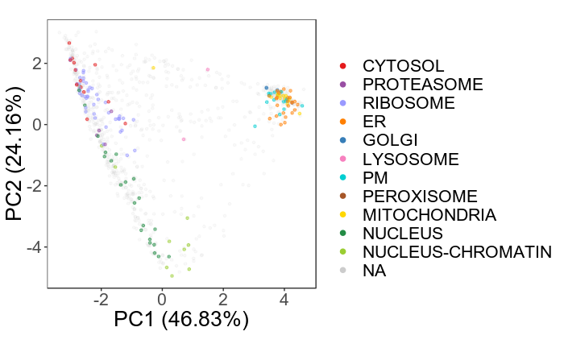

```r
print(p)
```

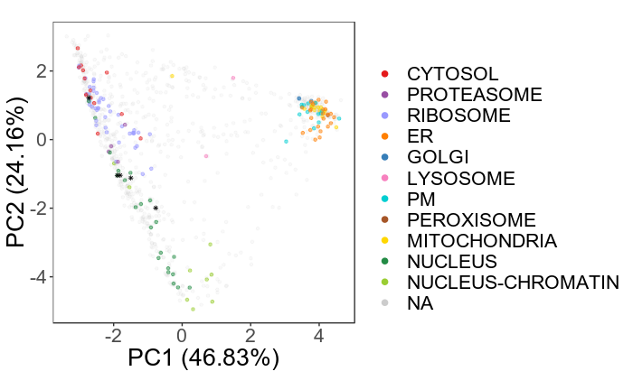

```r
ggsave("~/Desktop/delete_me3.png")
```

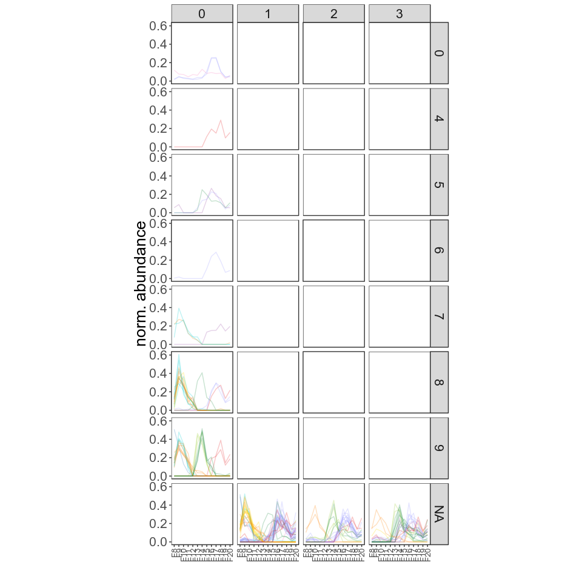

```r
p <- PlotMarkerProfiles(protein_quant_am, "markers", keep_markers=marker_classes, organelle_order=organelle_order) +
  facet_grid(zero_imputation_n~missing_n) +
  scale_colour_manual(values=m_colours, guide=FALSE) +
  theme(legend.position="none")
print(p)
```

```r
ggsave("~/Desktop/delete_me4.png")
```

Now we make a new set of markers designed to highlight functional groups of RBPs more usefully. First we need to define new sets of GO annotation proteins, where each marker belongs to only one group

```r
translocon <- human_go %>% filter(GO.ID=='GO:0071256') %>% pull(UNIPROTKB)
para <- human_go %>% filter(GO.ID=='GO:0042382') %>% pull(UNIPROTKB)
mrna_splicing <- human_go %>% filter(GO.ID=='GO:0000398') %>% pull(UNIPROTKB)
translation_init <- human_go %>% filter(GO.ID=='GO:0006413') %>% pull(UNIPROTKB)
translation_init <- setdiff(translation_init, names(markers_proteins)[markers_proteins=="RIBOSOME"])
cell_cell_adhesion <- human_go %>% filter(GO.ID=='GO:0098609') %>% pull(UNIPROTKB)
cytoskeleton <- human_go %>% filter(GO.ID=='GO:0005856') %>% pull(UNIPROTKB)
motor_activity <- human_go %>% filter(GO.ID=='GO:0003774') %>% pull(UNIPROTKB)
er_stress_response <- human_go %>% filter(GO.ID=='GO:0030968') %>% pull(UNIPROTKB)
nuclear_pore_channel <- human_go %>% filter(GO.ID=='GO:0044613') %>% pull(UNIPROTKB)
nuclear_pore_basket <- human_go %>% filter(GO.ID=='GO:0044615') %>% pull(UNIPROTKB)
tRNA_AA <- human_go %>% filter(GO.ID=='GO:0004812') %>% pull(UNIPROTKB)
#mrna_splicing <- setdiff(mrna_splicing, c(para, translation_init, cell_cell_adhesion, cytoskeleton, motor_activity))
#translation_init <- setdiff(translation_init, c(para, cell_cell_adhesion, cytoskeleton, motor_activity))
#cytoskeleton <- setdiff(cytoskeleton, c(para, cell_cell_adhesion, motor_activity))
#cell_cell_adhesion <- setdiff(cell_cell_adhesion, c(para, motor_activity))
#all_markers <- c(mrna_splicing, para, translocon, translation_init, cell_cell_adhesion, cytoskeleton, motor_activity)
#print(length(all_markers)==length(unique(all_markers)))
mrna_splicing <- setdiff(mrna_splicing, tRNA_AA)
all_markers <- c(mrna_splicing, tRNA_AA)
print(length(all_markers)==length(unique(all_markers)))
```

```
[1] TRUE
```

```r
rbps_markers <- markers_proteins
localisations_to_remove <- c("PEROXISOME", "PROTEASOME", "GOLGI", "LYSOSOME")
rbps_markers <- rbps_markers[!rbps_markers %in% localisations_to_remove]
rbps_markers[rbps_markers =="NUCLEUS-CHROMATIN"] <- "NUCLEUS"
print(table(rbps_markers))
```

```
rbps_markers
     CYTOSOL           ER MITOCHONDRIA      NUCLEUS           PM     RIBOSOME
          96          118          197          171          295           72
```

```r
new_markers <- c(#rep("PARASPECKLES", length(para)),
                 rep("mRNA splicing", length(mrna_splicing)),
                 rep("Aminoacyl-tRNA ligase", length(tRNA_AA))#,
                 #rep("TRANSLATION INITITAION", length(translation_init)),
                 #rep("CELL-CELL ADHESION", length(cell_cell_adhesion)),
                 #rep("MOTOR", length(motor_activity))#,
                 #rep("CYTOSKELETON", length(cytoskeleton))
                 )
names(new_markers) <- c(#para,
                        mrna_splicing,
                        tRNA_AA#,
                        #translation_init,
                        #cell_cell_adhesion,
                        #motor_activity#,
                        #cytoskeleton
                        )
print(table(names(new_markers))[table(names(new_markers))>1])
```

```
named integer(0)
```

```r
rbps_markers <- rbps_markers[!names(rbps_markers) %in% names(new_markers)]
combined_markers <- c(rbps_markers, new_markers)
print(table(combined_markers))
```

```
combined_markers
Aminoacyl-tRNA ligase               CYTOSOL                    ER          MITOCHONDRIA         mRNA splicing
                   42                    93                   118                   193                   321
              NUCLEUS                    PM              RIBOSOME
                  149                   295                    72
```

```r
print(table(names(combined_markers))[table(names(combined_markers))>1])
```

```
named integer(0)
```

```r
fData(protein_quant_am_no_glyco_yes_rbp)$new_markers <- NULL
protein_quant_am_no_glyco_yes_rbp <- addMarkers(protein_quant_am_no_glyco_yes_rbp, combined_markers, "new_markers")
```

```
Markers in data: 167 out of 485
```

```
organelleMarkers
Aminoacyl-tRNA ligase               CYTOSOL                    ER          MITOCHONDRIA         mRNA splicing
                   13                     5                     7                     2                    86
              NUCLEUS                    PM              RIBOSOME               unknown
                   12                     3                    39                   318
```

```r
fData(protein_quant_am_no_glyco_yes_rbp)$new_markers <- recode(
  fData(protein_quant_am_no_glyco_yes_rbp)$new_markers, "NUCLEUS"="Nucleus", "RIBOSOME"="Ribosome", "CYTOSOL"="Cytosol",
  "MITOCHONDRIA"="Mitochondria")
print(table(fData(protein_quant_am_no_glyco_yes_rbp)$new_markers))
```

```
Aminoacyl-tRNA ligase               Cytosol                    ER          Mitochondria         mRNA splicing
                   13                     5                     7                     2                    86
              Nucleus                    PM              Ribosome               unknown
                   12                     3                    39                   318
```

```r
fData(protein_quant_am_no_glyco_yes_rbp)$new_markers[fData(protein_quant_am_no_glyco_yes_rbp)$new_markers=="PM"] <- "unknown"
```

```r
new_markers_levels <- getMarkerClasses(protein_quant_am_no_glyco_yes_rbp, "new_markers")
p <- plotPCA(protein_quant_am_no_glyco_yes_rbp, "new_markers", re_order_markers=TRUE, marker_levels=new_markers_levels,
        m_colours=getClassColours()[c(1:5, 7, 10:20)], foi=nuclear_pore_channel)
```

```
the condition has length > 1 and only the first element will be used
```

```r
print(p)
```

[output not shown]

```r
p <- plotPCA(protein_quant_am_no_glyco_yes_rbp, "new_markers", re_order_markers=TRUE, marker_levels=new_markers_levels,
        m_colours=getClassColours()[c(1:5, 7, 10:20)], foi=nuclear_pore_basket)
```

```
the condition has length > 1 and only the first element will be used
```

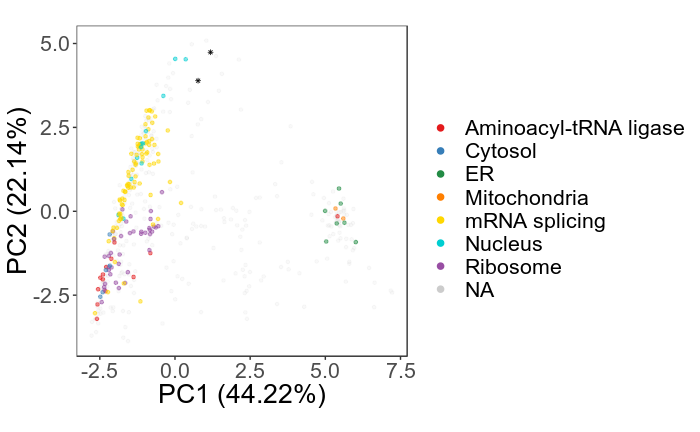

```r
print(p)
```

```r
getMarkerClasses(protein_quant_am_no_glyco_yes_rbp, "new_markers")
```

```
[1] "Aminoacyl-tRNA ligase" "Cytosol"               "ER"                    "Mitochondria"
[5] "mRNA splicing"         "Nucleus"               "Ribosome"
```

```r
set.seed(1)
proj <- make_proj("t-SNE", protein_quant_am_no_glyco_yes_rbp, "new_markers")
```

```r
capitalize(tolower("PM"))
```

```
[1] "Pm"
```

```r
proj_df <- proj$PCA_df
marker_levels <- setdiff(new_markers_levels, "unknown")
marker_levels <- marker_levels[c(2,3,4,6,7,1,5)]
#m_colours <- getStockcol()[c(1,7,4,3,2,5)]
m_colours <- cbPalette[c(6,3,2,4,8,7,5)]
proj_df$markers <- factor(proj_df$new_markers, levels=marker_levels)
print(table(is.na(proj_df$markers)))
```

```
FALSE  TRUE
  164   321
```

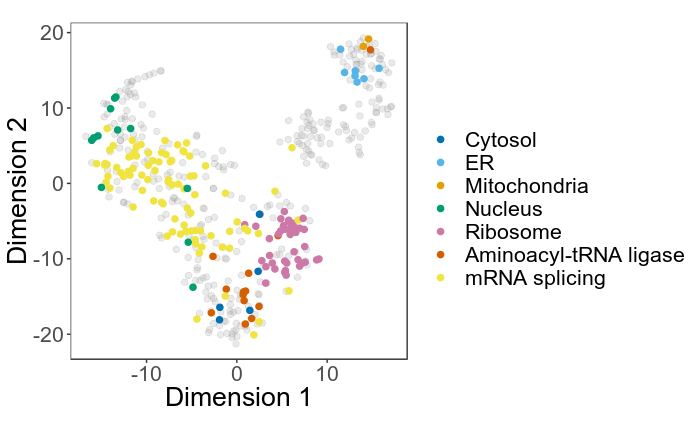

```r
proj_df$unknown <- proj_df$new_markers=="unknown"
p <- ggplot(proj_df, aes(X, Y, colour=markers)) +
    geom_point(aes(X, Y, colour=markers, alpha=unknown), size=2) +
    scale_alpha_manual(values=c(1,0.2), guide=F) +
    my_theme +
    scale_colour_manual(values=m_colours, na.value="grey60", name="", breaks=c(marker_levels)) +
    guides(colour = guide_legend(override.aes = list(alpha = 1, size=2))) +
    xlab("Dimension 1") + ylab("Dimension 2")
print(p)
ggsave("./Output/tSNE_RBP_markers.png")
```

```r
write.table(proj_df, "./Output/tSNE_projections.tsv", sep="\t", quote=FALSE, row.name=FALSE)
```

[figure not shown]

```r
protein_info <- read.delim("Input/Aggregated-proteins-2187-with-uniprot.tab") %>%
  dplyr::select(Entry, gene_name=Gene.names...primary..)
total.prot = readRDS("./Input/prot_res_20_fractions_imputed_markers.rds")
colnames(total.prot)[12] <- "0.948"
colnames(total.prot) <- c(seq(1,20,2), seq(2,20,2))
total.prot <- total.prot[,order(as.numeric(as.character(colnames(total.prot))))]
total.prot <- total.prot[,5:19]
total.prot = normalise(total.prot,"sum")
rbp.prot <- protein_quant_am_no_glyco_yes_rbp
colnames(rbp.prot) <- 5:19
print(dim(total.prot))
```

```
[1] 5610   15
```

```r
print(dim(rbp.prot))
```

```
[1] 485  15
```

```r
print(colnames(total.prot))
```

```
 [1] "5"  "6"  "7"  "8"  "9"  "10" "11" "12" "13" "14" "15" "16" "17" "18" "19"
```

```r
print(colnames(rbp.prot))
```

```
 [1] "5"  "6"  "7"  "8"  "9"  "10" "11" "12" "13" "14" "15" "16" "17" "18" "19"
```

```r
plotCombinedProfiles <- function(foi){

  foi_in_total <- intersect(foi, rownames(total.prot))
  foi_in_rbp <- intersect(foi, rownames(rbp.prot))

  foi_in_both <- intersect(foi_in_rbp, foi_in_total)

  print(foi_in_both)
  if(length(foi_in_both)==0){
    return(NA)
  }

  total_exprs_df <- exprs(total.prot[foi_in_both,])
  total_exprs_df <- melt(total_exprs_df)
  total_exprs_df$type = "All protein"

  rbp_exprs_df <- exprs(rbp.prot[foi_in_both,])
  rbp_exprs_df <- melt(rbp_exprs_df)
  rbp_exprs_df$type = "RNA-bound"

  #print(head(total_exprs_df))
  #print(head(rbp_exprs_df))
  #print(head(rbind(rbp_exprs_df, total_exprs_df)))

  p <- rbind(rbp_exprs_df, total_exprs_df) %>%
    merge(protein_info, by.x="Var1", by.y="Entry") %>%
    ggplot(aes(Var2, value, colour=type, group=type)) +
    my_theme + geom_line() +
    theme(aspect.ratio=1, axis.text.x=element_text(angle=90, vjust=0.5, hjust=1, size=10))  +
    xlab("") + ylab("norm. abundance") +
    scale_colour_discrete(name="", na.value="grey")

  if(length(foi_in_both)>1){
    p <- p + facet_wrap(~gene_name)
  }

  print(p)

  p2 <- p <- rbind(rbp_exprs_df, total_exprs_df) %>%
    merge(protein_info, by.x="Var1", by.y="Entry") %>%
    ggplot(aes(Var2, value, colour=type, group=interaction(type, gene_name))) +
    my_theme + geom_line() +
    theme(aspect.ratio=1, axis.text.x=element_text(angle=90, vjust=0.5, hjust=1, size=10))  +
    xlab("") + ylab("norm. abundance") +
    scale_colour_discrete(name="", na.value="grey")

  print(p2)

  invisible(list("p"=p, "p2"=p2))
}
```

```
 [1] "Q9NSE4" "P41252" "P54577" "P49589" "P49591" "P14868" "O43776" "P07814" "P47897" "P26639" "P26640" "P49588"
[13] "P41250"
```

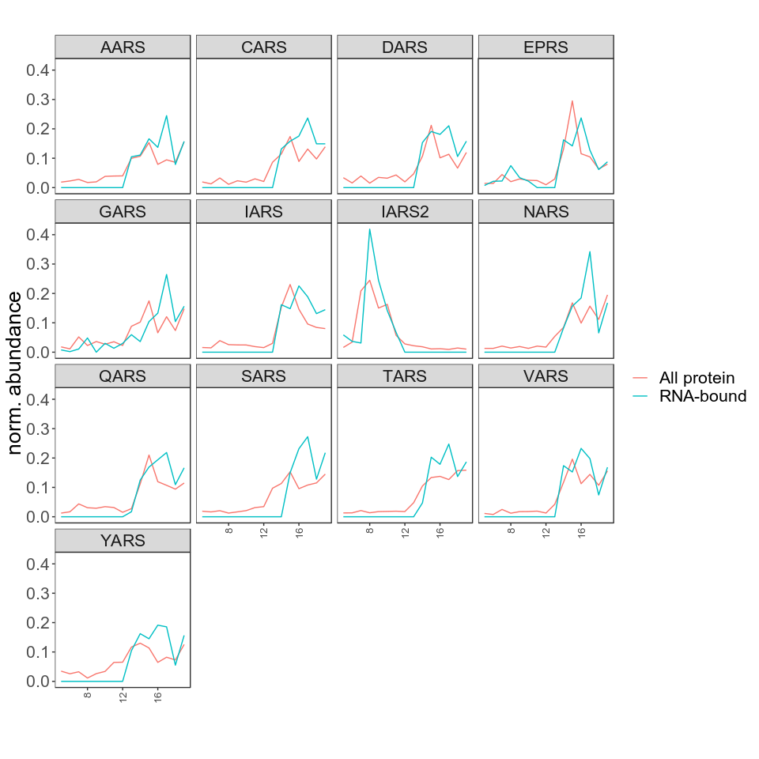

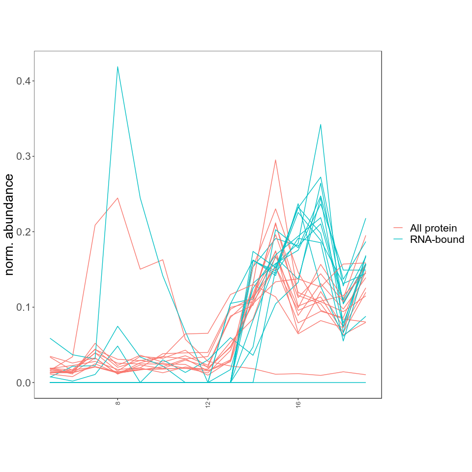

```r
plotCombinedProfiles(tRNA_AA)
```